# Social Network Effects on Productivity and Job Security: Evidence from the Adoption of a Social Networking Tool

Converted from PDF `Wu-SocialNetworksJobSecurity-2013-ISR.pdf` · 23 pages · anchors: page `#pN`, block `#pN-bK`

Page 1

[figure not shown]

NOTE: figure/graphic rendered as an image from the PDF; its content is not machine-readable text. Caption (if any) follows as the next block.

**text found inside the figure**

Information Systems Research

Publication details, including instructions for authors and subscription information: http://pubsonline.informs.org

Social Network Effects on Productivity and Job Security: Evidence from the Adoption of a Social Networking Tool

Lynn Wu,

To cite this article: Lynn Wu, (2013) Social Network Effects on Productivity and Job Security: Evidence from the Adoption of a Social Networking Tool. Information Systems Research 24(1):30-51. https://doi.org/10.1287/isre.1120.0465

Copyright © 2013, INFORMS

Page 2

### *Information Systems Research*

Vol. 24, No. 1, March 2013, pp. 30–51 ISSN 1047-7047 (print)  ISSN 1526-5536 (online) http://dx.doi.org/10.1287/isre.1120.0465

© 2013 INFORMS

## Social Network Effects on Productivity and Job Security: Evidence from the Adoption of

## a Social Networking Tool

#### Lynn Wu The Wharton School, University of Pennsylvania, Philadelphia, Pennsylvania, wulynn@wharton.upenn.edu

**Introduction** Social network theory predicts an information-rich network that is low in cohesion and spans structural holes to be associated with higher work performance. By linking unconnected groups, the brokers who bridge these structural holes, are endowed with early exposure to novel information and can act as hubs to facilitate information flow between otherwise disconnected groups. Studies have shown that people whose networks are rich in structural holes have a competitive advantage over their peers. They tend to receive superior performance ratings and higher compensation (Burt 1992, Lin 2001, Cross and Cummings 2004, Wu et al. 2009). For example, bankers with structurally autonomous or information-rich networks are more likely to be recognized as top performers (Burt 2000). Similarly, employees in research and development positions maintaining diverse contacts outside of the team are more productive than their peers (Reagans and Zuckerman 2001).

However, it is difficult to determine from past studies whether these network positions can be strategically acquired. Fortunately, the recent exponential growth in social media provides an unprecedented opportunity for individuals to actively manage their

networks, and for researchers to quantify whether individuals derive any benefits from using social media to manage their social connections. If social media can facilitate a change in people’s network characteristics, they can have a tremendous value for business processes, human resources (HR), and IT management. In this study, I address this important issue by examining whether, and if so, how the adoption of an enterprise social media tool within an organization can change social networks over time, and whether there are any economic benefits associated with such a change. This particular social media tool was developed specifically to help users find experts within the firm, providing employees an opportunity to strategically reach out to different groups of people, and thereby induce their network positions to be more structurally autonomous and informationrich. Examining the network change before and after using this expertise search tool, I show that social media have the potential to transform and disrupt existing organizational structures. This transformation can have important economic consequences, such as improving worker productivity and job security.

While it is important to quantify the performance improvements from a social media-induced network

30

Page 3

**Wu:** *Social Network Effects on Productivity and Job Security* Information Systems Research 24(1), pp. 30–51, © 2013 INFORMS 31

change, the question of how the change drives productivity gains remains open. Information benefits have been theorized to be the primary reason why an autonomous or information-rich network endows individuals with work advantage (Burt 1992). However, information transmitted inside a network is rarely directly observed. Thus, it is difficult to verify if a structurally autonomous network actually generates information benefits that ultimately affect performance. Moreover, these benefits are often bundled together in theoretical arguments, even though they are distinct and may affect work outcomes differently (Burt 1992, pp. 13–15). Depending on their nature, some information benefits may facilitate different organizational processes and, at times, have competing performance implications (Fernandez 1991). Thus, it is important to measure and classify various types of information benefits and understand how they affect work outcomes differently. With the advance of social media and communication tools, it is possible to precisely capture the content of people’s communications and use them to quantify various aspects of information benefits in an anonymous way.

Specifically, I show that an information-rich network, enabled by social media, can provide two types of information benefits, information diversity and social communication, and they affect work outcomes differently. I define information diversity as the heterogeneity of the information content in individuals’ electronic communications. As a measure, it combines access to and timing of information. Earlier access to a variety of information sources allows an individual to gather more and more diverse information, which can be instrumental to productivity. I also measure the frequency of social communications and informal activities in a person’s electronic communications. While diversity of information topics is theorized to improve work performance, intensity of a certain type of information, such as social communication, can also be beneficial, especially in situations where referrals are needed (Burt 1992).

Viewing information diversity as instrumental and social communication as expressive, I find that an information-rich network, characterized by low cohesion and rich in structural holes, can generate both instrumental and expressive types of benefits. This finding runs contrary to the belief that, due to their contrasting natures, there is a trade off between having both in a network (Bales and Slater 1955, pp. 290–292; Etzioni 1965, pp. 696–697; Slater 1965). While it is possible to have both instrumental and expressive benefits in an information-rich network, there is a trade off between the two in the relative return on the investment from either socializing to form friendships or gathering diverse information. The decision to mobilize friendship or information

diversity may depend on the work outcome one hopes to achieve. Specifically, I find that information diversity derived from an information-rich network is more associated with improving productivity, but that social communication is more positively correlated with job security. To exemplify their possible trade off, I show that information diversity and social communication are substitutes in generating billable revenue and avoiding layoffs.

### **Theory**

**Impact of Social Media on Networks and Work Outcomes** Ample evidence has documented a strong correlation between certain social network attributes and superior work performance (Burt 1992, Ancona and Caldwell 1992, Reagans and Zuckerman 2001, Zaheer and Bell 2005, Wu et al. 2009, Aral et al. 2012). One of the most prominent features of social network structure, which has received an enormous amount of theoretical and empirical attention, is brokerage or information-rich networks (e.g., Burt 1992, Granovetter 1973), characterized by a network that is low in cohesion and structural equivalence and rich in structural holes. For example, Burt (1992, 2000, 2004) shows that structural holes can create a competitive advantage for individuals in dimensions such as wages and promotion. He attributes the normalized performance differences to actors’ ability to access and gather information from nonredundant social groups.

However, how information-rich networks are obtained is subject to debate. Some have argued that inherent traits and past history constrain changes in social structure, making it difficult to alter a person’s network (Powell et al. 2005), and consequently, the effect of network structure on performance may be the result of other hidden and unobserved factors. Others believe that purposeful actions allow actors to build and change their networks to their advantage (Burt 1992). Resolving this debate is difficult because it is extremely challenging to manipulate people’s experience and social structure in real life. Fortunately, the growth of social media in recent years provides an unprecedented opportunity to address this issue by allowing individuals to actively manage their networks. Many social networking tools have sophisticated search engines, helping people to find others and form connections (Piskorski et al. 2011). In my research context, a social media search tool was designed specifically to help individuals find people with certain expertise. Through the use of this tool, people are more likely to be exposed to a more diverse group of contacts from different parts of the organizational network. Over time, individuals’ networks

Page 4

**Wu:** *Social Network Effects on Productivity and Job Security* 32 Information Systems Research 24(1), pp. 30–51, © 2013 INFORMS

can become more diverse and richer in information. If having an information-rich network can improve work outcomes, it is reasonable to expect the same for having one that is enabled by social media.

Hypothesis 1 (H1). *Acquiring a more information-rich network, enabled by social media, improves work outcomes.*

**Information-Rich Network, Information Diversity and Social Communication** While an information-rich network is assumed to confer information benefits by providing access to novel information from loosely connected network neighborhoods, these benefits are rarely directly observed and measured. The vast majority of empirical work on network and information is content agnostic (Hansen 1999). As Burt (2008) explained, network structure is often used as a proxy for information flow because structures can be measured more easily than the actual content of what is transmitted in the network. He calls for the next phase of network research to investigate how individuals gather information from their network positions. While some research, especially in the connectionist perspective, has also stressed the importance of measuring the content of the network, they often characterize the network as channels, pipes, or conduits, and the content as attributes of the nodes (Podolny 2001, Rodan and Galunic 2004). Under this assumption, information flow is implicitly assumed to be proportional to the distribution of links among nodes of the network. However, information exchange may occur strategically; individuals do not always share all available information (Reagans and McEvily 2003, Aral and Van Alstyne 2011). Hence, it is critical to open up the black box of networks to investigate the information that is being transferred between individuals inside a network. Instead of using characteristics of nodes as a proxy for information content and structural topology as a proxy for information flow, the next phase of research should examine whether, and if so, how network positions generate information benefits (Burt 2008). More importantly, information mechanisms are often bundled together in theoretical argument. Opening the black box of network structure is important not only to quantify the actual information benefits, but also to *distinguish* how these benefits affect different organizational processes and outcomes.

However, measuring the information flow inside a network is extremely difficult, because it is hard to directly observe the information content in people’s interactions. To the best of my knowledge, quantifying and differentiating various types of information benefits have not been done before. I address this issue by examining two types of information benefits— information diversity and social communication— through encoded electronic communication such as email, text messages, and calendar events. Information diversity can be viewed as a combination of information access and timing. Specifically, I compute the diversity of information content using the dissimilarities of the topics in a person’s electronic communications. Obtaining information from diverse sources is the key to making better decisions, solving difficult problems, and generating innovative solutions. Social communication, on the other hand, measures how much of an actor’s communication is related to socializing and informal social activities. Instead of measuring the heterogeneity of information, social communication focuses on the intensity of one type of communication. Through these socializing activities, network contacts get to know an individual better and are more likely to serve as strong personal advocates, particularly in situations of crisis and uncertainty (Ibarra 1995). Having a diverse circle of friends is more likely to help the actor, trumpeting his accomplishments and advertising his work to a diverse group of people, including decision makers.

Information diversity and social communication can also be viewed in the framework of expressive and instrumental network relationships, where information diversity is a proxy for instrumental relationships and social communication is a proxy for expressive relationships. Research on expressive and instrumental networks often focuses on the content of relationships (Borgatti and Foster 2003), as opposed to

Page 5

**Wu:** *Social Network Effects on Productivity and Job Security* Information Systems Research 24(1), pp. 30–51, © 2013 INFORMS 33

the structural properties. It has been argued that topological studies of networks often neglect the resources flowing between actors and focus exclusively on the structural perspectives (Snijders 1999, Lin 2001). This is problematic because actors are only successful when they can mobilize resources from their network contacts (Podolny and Baron 1997). One way to classify these resources is through their instrumental or expressive nature. Instrumental ties are often used to exchange work-related resources, and they typically involve actions that seek information, expertise, and professional advice (Lincoln and Miller 1979, Fombrun 1982). Expressive ties, on the other hand, are often affective and friendship based and involve the exchange of alliance, trust, and social support (Krackhardt 1995).

However, the literature on instrumental and expressive networks focuses more on the tie contents than on the network’s structure. Similarly, the structural perspective, such as the structural holes theory, often disregards instrumental and expressive elements in the network. Drawing upon both literatures, I show that benefits derived from an information-rich network can have both instrumental and expressive properties. Specifically, information diversity is coupled with instrumental actions, much as social communication is with expressive actions. Instrumental actions, which generate task-related information and advice, increase the information diversity crucial to higher work performance. Expressive actions such as social communication generate friendships that are more likely to advance and promote an individual, helping the person avoid crises and find new opportunities (Ibarra 1995). While differing in their instrumental and expressive natures, both information diversity and social communication enable an information-rich network to generate superior return by various performance measures (Burt 1992). Thus I bridge the gap between the structure- and tie content-centric views by showing that an information-rich network can generate both instrumental and expressive properties.

Hypothesis 2A (H2A). *Information diversity increases as a network becomes more information-rich.*

Hypothesis 2B (H2B). *Social communication increases as a network becomes more information-rich.*

Interestingly, this is contrary to the notion that it is difficult to build both expressive and instrumental networks because they are often at odds. Some have argued that expressive and instrumental activities often conflict because it is difficult to fill both roles at the same time (Bales and Slater 1955, Etzioni 1965, Slater 1965). For example, having friendship or expressive ties can make it difficult for a manager to enforce rules and apply sanctions to subordinates.

Thus, expressive ties dampen the effect of instrumental actions or vice versa, leading to a trade-off in having either one or the other (Fernandez 1991). Similarly, because people tend to distinguish between the two roles, expressive and instrumental networks can have a substitutive relationship (Homans 1974, Fernandez 1991). Thus, while it is possible for an informationrich network to have both types of benefits, there could potentially be trade-offs between the two in how they impact work outcomes.

**Trade-Offs between Information Diversity and Social Communication** The trade-off between information diversity and social communication lies in the limitation to take advantage of both types of social capital to achieve desired outcomes. To understand how information diversity and social communication are used to achieve different goals, I examine their effects on two types of outcome: worker productivity and job security. Worker productivity is measured using billable revenue, which is an objective measure of work performance and is one of the most salient metrics for evaluating consultants. Information workers, such as consultants, are especially valued for their ability to access pertinent information, which can have two effects on enhancing work performance. First, accessing information related to the task at hand directly improves the quality of work. Second, accessing diverse information also exposes actors to new opportunities and useful resources (Burt 1992, 2004). Consequently, these actors would be the first to learn about a new opportunity, placing them at the front of the queue to strategically seize the opportunity. In the IT consulting business, accessing information expeditiously is the key to performance. Since consultants’ performance is largely measured by billable revenue, it is crucial to do well in the current project as well as to spend time to look for future opportunities. Knowing where to obtain expertise helps an individual solve difficult problems and produce highquality work, enhancing one’s reputation and future prospects for finding opportunities. All else equal, a manager would prefer reputable consultants to handle important projects, because they are more likely to satisfy customers and generate repeat business. Thus, if an information-rich network is to produce informational benefits, it should have a strong effect on information workers in knowledge-intensive settings.

Social communication may also help improve billable revenue. By socializing informally with a diverse group of people, consultants are more likely to encounter opportunities serendipitously. Friends can also provide information that helps increase billable revenue. The operative factor in these situations, however, is information diversity resulting from having

Page 6

**Wu:** *Social Network Effects on Productivity and Job Security* 34 Information Systems Research 24(1), pp. 30–51, © 2013 INFORMS

an information-rich network, including information gathered from work-related interactions with friends. On the other hand, social communication is distinct from information diversity in that it captures the intensity of one type of information that helps build stronger personal relationships. Through informal interactions, network contacts are more likely to know one’s expertise and be able to serve as one’s advocate to others. Although having someone to advocate for an actor is helpful, it may not generate billable revenue directly—because, ultimately, having access to useful information, opinions, and perspectives is responsible for solving difficult cases and generating profits. Hence, I hypothesize that a performance improvement arises from an information-rich network primarily by means of information diversity, and not necessarily by means of social communication.

Hypothesis 3A (H3A). *Information diversity has a stronger effect on improving productivity than social communication.*

While having a diverse body of information from an information-rich network is helpful for productivity, information-rich networks can also provide other types of benefits, such as social communication. Social communication measures the intensity of one type of information that helps with building friendships. Friends tend to protect another in crisis situations, such as layoffs. Through social communication to generate affective relationships, individuals can mobilize their network contacts to avoid a crisis at work.

Thus, social communication can be critical for job security. An employee is much less likely to be laid off if a wider range of people, including managers, have a favorable opinion of the person. Social contacts can greatly facilitate this process by functioning as a means to broadcast one’s achievements to others. The advantages of the referral process also flow from the theory of recognition heuristics (Goldstein and Gigerenzer 1999, 2002); according to this theory, people place higher values on objects they recognize than on objects they don’t, regardless of their actual values. Thus, when key decision makers have heard of a person, that recognition value alone may keep the person from being laid off. In contrast, people with comparable work evaluations, may face a higher risk of being laid off if no one is advocating for them because decision makers are less likely to know their contributions to the organization. In interviews of managers who participated in layoff decisions, many of them expressed the importance of reputation and general awareness of a person’s work. Below is a quote from a senior manager.

When we sit down at a meeting to make layoff decisions, we discuss people’s work and what we think of their work, not just billable hours. Usually, when more

than one person in the meeting is aware of the person or speaks on his behalf, this person is much less likely to be laid off than someone nobody has heard of.

This statement indicates that actors with advocates are able to effectively advertise and promote their work indirectly through social contacts. Consequently, their visibility is increased, and they are less likely to be laid off.

Information diversity can help with job security through improving one’s work productivity, because firms are less likely to lay off their star performers, who disproportionately contribute to the bottom line. However, social communication plays a more important role in improving job security than does information diversity, possibly because being laid off does not just affect that person alone; it can affect the team and colleagues who are connected to the person. Once the person leaves the organization, he is permanently removed from the social network of his contacts, and network destruction from layoffs can have a drastic effect on the remaining employees (Krackhardt and Porter 1985, Shah 2000).

Billable revenue, on the other hand, is more likely to affect just the person himself, because a person’s own billable revenue does not directly impact other group members, as compared to layoffs. Accordingly, the mechanism for reducing the layoff risk is different from the one that generates billable revenue. When network contacts are friends, they are likely to protect the person from layoffs, because not only would they lose a potentially important information source, they may also experience the negative consequences of losing a friend at work (Shah 2000). Informal activities and social communication with a diverse group of people can promote friendships that, in turn, shield a person from being laid off. Thus, social communication can improve job retention more than information diversity, even after controlling for billable revenue. Figure 1 captures the theory development and hypothesis testing.

Hypothesis 3B (H3B). *Social communication has a stronger effect on reducing the risk of being laid off than information diversity.*

**Data and Setting** To test these hypotheses, I have collected data at a large information technology firm. High-tech firms have been a fertile ground for researchers to understand how network characteristics play important roles in information-intensive work settings, such as the search and transfer problems across organizational units (Hansen 1999), research and development productivity (Reagans and Zuckerman 2001), and mobility in the workplace (Podolny and Baron 1997).

Page 7

**Wu:** *Social Network Effects on Productivity and Job Security* Information Systems Research 24(1), pp. 30–51, © 2013 INFORMS 35

**Figure 1 Hypothesis Testing**

Social media

[figure not shown]

NOTE: figure/graphic rendered as an image from the PDF; its content is not machine-readable text. Caption (if any) follows as the next block.

**text found inside the figure**

H1 Structurally diverse networks

H2A

+

+ H2B

information

diversity

Instrumental verses expressive

Social communication + Retention

Ego verses group

billable revenue

H3A

H3B

+

If information benefits derived from network positions matter for performance, they should matter especially in a knowledge-intensive setting, such as in the high-tech sector.

To characterize the social network in the firm, I captured the internal electronic communication exchanges. Previous work has validated the benefits of using electronic communication data to understand intraorganizational networks within a firm or an institution (Wu et al. 2004, Kossinets and Watts 2006). While using digital traces left by users can construct a more accurate portrait of a network’s topological structure, more importantly, it allows for the direct observation of the information transmitted inside the network. Examining the variation of the information content across individuals can definitely confirm whether the information-based assumptions about the network are valid (Burt 2008). Specifically, distinct topics in each person’s electronic communications can be found to capture the information heterogeneity across individuals. Furthermore, I extend the content analysis by examining social communication, measuring it using a friendship index that quantifies informal and socializing activities in individuals’ communication.

Without recording of the content of people’s communication transmitted inside an electronic communication network, it would be difficult to measure if information benefits actually exist and if there are different types of information benefits. Traditionally, content analysis is often done through detailed ethnographic studies. While these studies are useful, they are also limited because it is difficult to capture the communication content for a large group of people using ethnography. Similarly, traditional social network data is generated using self-reports such as surveys and questionnaires that require the subjects to recall their network connections. While respondents are generally good at remembering recent and frequent interactions, they are poor at recalling weak and distant ties (Marsden 1990, Krackhardt and Kilduff 1999). The recall bias as well as the general inaccuracy in memory can be problematic for

constructing network relations that are socially distant, resulting in errors in measuring many network parameters (Marsden 2005, Kumbasar et al. 1994). Using the archive of electronic communications directly can greatly alleviate this type of bias, because electronic records can precisely capture when and what exact information content is exchanged between actors. The caveat is that electronic communications does not include face-to-face conversations, and thus the network constructed may be biased. However, because instant messages as well as calendar events are recorded, they can capture some aspects of faceto-face and telephone communications.

I focus on employees in the consulting division of a firm whose primary function is to solve problems for clients and generate profits through billable revenue. Typically, consultants are involved in four broad categories of projects: IT consulting, business processes, application supports, and outsourcing services. Consulting projects are, in general, information intensive and require solving difficult problems for the client. According to qualitative interviews, consultants often spend a large amount of time assembling, analyzing, and assessing information gathered from various sources to fully understand clients’ problems and make decisions and recommendations based on the information. To access diverse information that is critical for decision making, consultants often need to reach out to experts within the organization. Having connections to the experts either directly or through network connections is crucial for the consultants to gather and integrate information into viable solutions. Satisfying clients is extremely important because generating repeat business is the key for maintaining a continuing stream of revenue and avoiding bench time.

In addition to working on the current project, consultants also have to look for future projects. Consulting work in this firm functions like an internal labor market. To avoid bench time, consultants constantly spend time searching for future opportunities. While an internal placement manager is assigned to each consultant, the manager has limited capacity

Page 8

**Wu:** *Social Network Effects on Productivity and Job Security* 36 Information Systems Research 24(1), pp. 30–51, © 2013 INFORMS

to help individual consultants. Qualitative interviews indicate that a typical placement manager is responsible for 50–100 consultants at a time, and thus relying on the placement manager alone is not sufficient to find suitable projects as needed. Accordingly, consultants need to be proactive to find opportunities, and social contacts can play an important role in this process. Having access to information about project opportunities from social contacts is useful, because hearing about an opportunity early gives a consultant a timing advantage in applying for the job. Obtaining more information about the project and the person leading the project also helps the consultants to present their skills strategically as suiting the needs of the project lead. Hence, they are more likely to be hired.

**Data** To understand how social networks affect productivity and job security, I analyze a social network derived from the electronic communications of 8,037 employees over two years. The data contains email, calendar events, and instant messages inside a global information technology firm. To the best of my knowledge, this is the largest social network ever tapped to study the impact of social networks on work outcomes in an information-intensive industry. The data is collected using a privacy-preserving social network analysis system (Lin et al. 2008) that deploys social sensors to gather, crawl, and mine various types of data sources, including the hierarchical structure of the organization, individual role assignments, the encoded content of email and instant messages, and calendars of employees who volunteered their data for research.

The system is deployed globally and has collected detailed electronic communication records of 8,037 volunteers. Although the volunteers only represent about 5% of the global population of the firm, it represents about 15% of employees in English-speaking regions and 23% of employees in the consulting services, which will be the primary focus in this study. To alleviate the potential problems arising from the missing parts of the whole company’s network, I only examine the local network structure of each volunteer, because the system captures all the direct communications that the volunteers are involved in, including those with the nonvolunteers who are not a part of the study. Furthermore, because more than 50% of the direct contacts of the volunteers (one degree away) are also volunteers themselves, I can establish their dyadic relationships. For the case when the network contacts are not volunteers, it is still possible to make some inference about their network connections by examining if they co-occur frequently in the same email, instant messaging (IM), or calendar event. When two people (B and C) are listed together

as the correspondents of a third (A), they (B and C) are likely to be connected to each other as well. However, some connections among the nonvolunteers may still be missing, and the network structural parameters may be biased as a result. This is a common problem for network studies in the field, and requires setting a boundary on the population studied. But the missing connections among nonvolunteers would not bias the content analysis that calculates the parameters of information benefits using the electronic communication records of the volunteers, which is fully captured.

From these volunteers, it is also possible to derive a partial social network of everyone in the firm. However, I constrain the analysis to focus on the subnetwork for the 8,037 volunteers whose complete electronic communication data is available. To eliminate any potential bias from the volunteered data, I compare the job roles, demographics, the types of business functions, and hierarchical ranks of the volunteers with the rest of the firm. I find minimal differences between the two populations. I also compare the probability of being laid off between the two groups and find that being a volunteer is not a statistically significant predictor at the time when users became volunteers. With a large sample of more than 8,000 people, there is sufficient variation to detect at least the local average effect from networks and information in this subpopulation of volunteers.

To construct a precise view of the network that reflects the real communication patterns among actors, I eliminate spam and mass email announcements. Because each electronic message includes a time stamp, I can map a dynamic panel of social networks from January 2007 to January 2009. Each monthly network is built using a sliding window of six months with a one-month stepsize, and includes all the electronic messages in the current month, plus three months prior and two months after the current month. This construction of network panels can more accurately reflect the network relationships than just the network activities in a single month. Using the communication data, I construct a network panel of 17 periods for 8,037 employees, which provides an opportunity of rare scale and scope to study how a person’s social network evolves over time.

To explore how social networks are related to work performance, I obtain detailed financial performance records of more than 8,000 consultants. I focus on 2,038 consultants in this sample who have volunteered their electronic communication data and the 2,592 projects that these consultants participated in from January 2007 to January 2009. The sheer volume of the data allows a more precise estimate of how population-level topology in a network and information content, such as information diversity and

Page 9

**Wu:** *Social Network Effects on Productivity and Job Security* Information Systems Research 24(1), pp. 30–51, © 2013 INFORMS 37

**Table 1 Summary Statistics for Person-Level Networks**

[output not shown]

NOTE: table converted from PDF layout to HTML text; cell boundaries are reconstructed. See PDF if exact alignment matters.

**Table 2 Summary Statistics on Consultants**

[output not shown]

NOTE: table converted from PDF layout to HTML text; cell boundaries are reconstructed. See PDF if exact alignment matters.

social communication, affect worker productivity and job security. To protect the privacy of the volunteers, their identities are replaced with hash identifiers, and the content of their messages is also encoded. Tables 1 and 2 show the summary statistics of these consultants, including their demographics and job roles as well as network characteristics.

To study the effect of network positions on job security, I use data during an off-cycle and unexpected round of layoffs in January 2009 when approximately 8% of the work force is eliminated because of the severe global recession. The firm’s corporate policy allows for a two-month grace period during which the laid-off employees could retain their work privileges, including access to the corporate email system, intranet, and internal job postings. If they were able to find other positions within the firm during the grace period, they could be internally transferred, and thus remain at the firm. However, due to the recession’s severity, the firm simultaneously instituted a worldwide hiring freeze, making such internal transfers unlikely. Although I have no roster of exactly who was laid off, I can infer one by comparing the human resource (HR) directory shortly after the layoff announcement and right after the actual layoff event. From the difference between the two HR databases, I can derive who has left. It is possible that some employees may have left voluntarily, although unlikely in light of the severe recession and the difficult labor market worldwide, especially in North America. Several regional offices were closed and everyone in them was laid off. I exclude them from the data set.

**Dependent Variables** The dependent variables are two types of work outcomes: worker productivity and job security. First, I measure worker productivity using the monthly billable revenue generated by each consultant in a two-year period from January 2007 to January 2009.

Billable revenue is a clear and objective productivity measure widely adopted for evaluating the performance of information workers such as consultants, lawyers, and accountants. Interviews with managers show that billable revenue is an important performance benchmark, especially in the long run. It is possible that inefficient consultants may generate more billable hours in the short run, because they take longer to complete a task. However, this is not sustainable in the long run because a typical project on average lasts only about six months. As consultants are continuously looking for future project opportunities to maintain high utilization and avoid bench time, having a reputation for being efficient and producing quality work is critical. Inefficient consultants would not find new projects as easily as efficient ones because project managers would rather choose the best and most efficient consultants for their projects when possible. Thus, while inefficient consultants could potentially bill more hours in the short run, their billable revenue would suffer in the long run. Furthermore, the project managers may adjust the billable hours downward if they believe that the work does not deserve the hours it took. In this case, an inefficient consultant could be spending 10 hours on a project but only able to bill 5 hours.

The second dependent variable of interest is job security, as measured by whether a consultant was laid off in January 2009 amidst the worst financial crisis since the Great Depression. A sudden unexpected layoff eliminated 8% of the work force. Measured using job retention, the variable is binary, equaling 0 if a person is laid off and 1 if a person is retained.

**Explanatory Variables** I use Burt’s measure of network constraint (Burt 1992, pp. 54–55) to measure the degree of having an information-rich network.

X

**equation / math rendering (image)**

NOTE: contains mathematical notation; text above is the PDF text layer and symbols may be mis-extracted. Image shows the original.

*j*

*pij* +

X

**equation / math rendering (image)**

NOTE: contains mathematical notation; text above is the PDF text layer and symbols may be mis-extracted. Image shows the original.

*q*

*piqpqj*

2

*Network constraint Ci* measures the degree to which an individual’s contacts are connected to each other as well as their connections to the individual. *Pij* is the proportion of actor *i*’s network time and energy invested in communicating with actor *j*. Network constraint is a local property that measures the cohesiveness of a person’s network (Burt 1992), and brokerage or having an information-rich network is the opposite of network constraint and is computed as 1 −*Ci*. Because relationships may erode over time, I use a six-month sliding window of electronic communication to gauge the network relationships in the current month.

Page 10

**Wu:** *Social Network Effects on Productivity and Job Security* 38 Information Systems Research 24(1), pp. 30–51, © 2013 INFORMS

*Pij* is calculated from the tie strength, which is measured using the frequency of one’s electronic communications. Granovetter (1982) described four identifying properties for the strength of ties: time, emotional intensity, intimacy, and reciprocity. In practice, tie strength has been measured in many ways. Some use reciprocation to represent strong ties and a lack of reciprocation to represent weak ties (Friedkin 1982). Others have included the recency of contact or the frequency of interactions as a surrogate for tie strength (Granovetter 1973). To measure the tie strength in electronic communications, I primarily use the frequency, but with some modifications.

Because a single electronic message does not constitute an actual tie, especially when it is sent to a large number of people, counting any message exchange between actors as a dyadic tie would overestimate the actual number of ties. Thus, I eliminated all messages that have more than 15 recipients (Lin et al. 2008). In addition, to accurately reflect the tie strength between two actors, I normalized the measure to an interval between 0 and 1, with 0 indicating no tie between the two actors and 1 indicating the maximal tie strength (Lin et al. 2008). The detailed calculation is described below:

*Tie*_*Strengthij* =

*ij<sup>5</sup>*

Max*k* log*4X*<sup>′</sup>

*ik<sup>5</sup>*

*X*<sup>′</sup>

*i1j* <sup>=</sup>

where *Xij* is the total number of electronic messages between actors *i* and *j*. Basically, the formula indicates that a tie exists only when the number of electronic messages between two actors reaches a certain threshold. This threshold is personalized; for active users of electronic media, the threshold to register a tie is higher than for those who seldom use electronic media. This measure of tie strength has been extensively tested and shown to accurately reflect the tie strength between actors (Lin et al. 2008).

**Content Analysis** To measure information diversity and social communication, I use the content of electronic communications, after ensuring the privacy of the messages is preserved. Individuals are hashed with unique classifiers, so it is impossible to determine their identities. To preserve the privacy of each message, the original text is also not recorded. Instead, a set of tokenized one-gram and two-gram key words is created for each message after eliminating stop words and stemming. Stop words are common words such as articles (“a,” “an,” “the”) and prepositions (e.g., “from,” “of,” “to”). Stemming involves stripping each word to its root. For example, the word “running”

will be recorded as its root, “run.” With these precautions, it is virtually impossible to reconstruct the original message from these tokenized key words, which are further anonymized with hash identifiers to preserve privacy.

ID*<sup>i</sup>*

*t* <sup>=</sup>

P*N*

**equation / math rendering (image)**

NOTE: contains mathematical notation; text above is the PDF text layer and symbols may be mis-extracted. Image shows the original.

*i <sup>55</sup>*<sup>2</sup>

*N*

Our measure differs from earlier information diversity measures, such as vector space model (VSM), which is used in Aral and Van Alstyne (2011). The

1 Given a document corpus, LDA models each document *d* as a finite mixture over an underlying set of topics, where each topic *t* is characterized as a distribution over words. A posterior Dirichlet parameter *g4d3t5* can be associated with the document *d* and the topic *t* to indicate the strength of *t* in *d*. For details of the algorithm, please refer to Blei et al. (2003).

Page 11

**Wu:** *Social Network Effects on Productivity and Job Security* Information Systems Research 24(1), pp. 30–51, © 2013 INFORMS 39

**Figure 2 Snapshot of Expertise-Find**

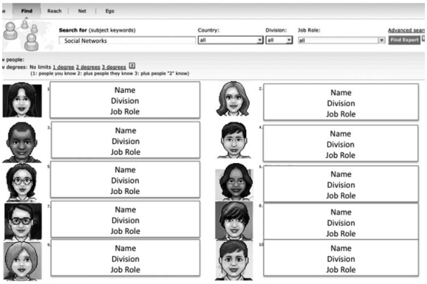

NOTE: figure/graphic rendered as an image from the PDF; its content is not machine-readable text. Caption (if any) follows as the next block.

Note. Search result from searching for the phrase “Social Networks.”

problem with the VSM approach is that the word order is not taken into account in the classification, but different word orders in the English language can completely change the original meaning, rending VSM less effective. LDA, on the other hand, takes the word order into account, and can thus significantly improve the quality of the topic classification. According to the machine learning community, LDA has become the preferred model to classify topics (Blei et al. 2003).

To measure social communication, I create a friendship index. First, I obtain a dictionary of every word ever used in the corpus of electronic messages. Each word is ranked by its term frequency-inverse document frequency (TF-IDF)<sup>2</sup> weight, which measures how important a word is to a document. I then use this list to create a sublist of words that are related to social communications and social activities with friends but also have relatively high TF-IDF values. For example, some examples of key words are “lunch,” “coffee,” “football,” and “baseball.” Two firm employees who had extensive experience at the firm for many years also verified that the words on the list are often used for social and informal activities. An employee on the development team

2 It is often used in information retrieval and text mining. The weight is a statistical measure used to evaluate how important a word is to a document. The importance increases if the word is rarely used. Frequently occurring words such as “have” will have relatively low TF-IDF weights, whereas a relatively exotic word such as “hematoma has a high weight.”

calculated the frequency of this set of words in each person’s monthly communications.

While finding a topic on social communication using LDA is ideal, it is difficult to characterize what the topic actually entails because only the hashed tokens of the words associated with each topic are observed. Masking words with tokens is necessary to preserve user privacy. However, this process also takes away the true meaning of the words, making it impossible to know the meaning of each topic. Hence, finding a topic that represents social communication is difficult. A friendship index is instead used to capture social communication, and is a relatively intuitive measure. Below, I define friendship index as the ratio of words relating to social activities to the total number of words. A high value of friendship index indicates a more intense use of social communication.

*Friendship*_*Index* = *<sup>Words</sup>*<sup>_</sup>*<sup>related</sup>*<sup>_</sup>*<sup>to</sup>*<sup>_</sup>*<sup>social</sup>*<sup>_</sup>*<sup>activities</sup>*

*Total*_*number*_*of* _*words*

**Control Variables** Control variables include individuals’ demographics such as gender, managerial roles, and job ranks. A managerial role is a dummy variable indicating whether the person is a manager. Job ranks have an ordinal value ranging from 6 to 12, where level 6 is the most junior consultant while level 12 is an executive vice president. A dummy variable is also created for each job rank. To control for the differences across various divisions and geographical locations, I include a dummy variable for each business division as well as a dummy variable for each geographical location. To

Page 12

**Wu:** *Social Network Effects on Productivity and Job Security* 40 Information Systems Research 24(1), pp. 30–51, © 2013 INFORMS

control for the current work load, I include the average monthly revenue in the past six months. Lastly, to control for individual preferences to use electronic media, I include a person’s total number of electronic messages (email, calendar, and IM) in a month.

### **Identification**

**Use of Technology Adoption as an Instrumental Variable (IV) for Network Positions** Despite the overwhelming evidence for a strong correlation between certain network positions and work outcomes, the causal mechanism underlying the association is underexplored (Reagans and McEvily 2003). A plausible explanation is that people actively seek high performers for advice and collaboration, and hence high performers tend to display a structurally autonomous and information-rich network. Similarly, certain individual characteristics may manifest in social networks. For example, a popular person tends to have a more information-rich network, which may also enable the person to be an effective employee in an organization. In essence, individual traits or past actions are the omitted variables that mediate both network positions and performance (Powell et al. 2005), so their observed relationship may be spurious. That there are positive correlations between certain individual traits and network positions suggest that individual heterogeneity may moderate the relationship between network positions and performance (Hargadon and Sutton 1997; Burt 2004, 2007). For example, Burt and Ronchi (2007) suggest that high-status individuals such as executives are more likely to occupy brokering positions in the firm because their roles as executives require them to reach out to a diverse range of people. Similarly, Burt (2007) suggests that inherent abilities, such as possessing performance-enhancing cognitive skills, are ultimately responsible for improving work performance. In short, in this view, network positions are a function of human capital.

To detect a causal relationship between network positions and work outcomes, an exogenous source of variation is needed (Munshi 2003). I exploit the adoption of a social networking tool that can exogenously change a person’s network position over time by allowing users to search for experts using keywords. Because people resort to technologies only when they cannot find relevant experts in their immediate network neighborhood (Borgatti and Cross 2003), the experts that the users found via search are often outside of the person’s existing social circle. If users decide to reach out to these experts, the users’ networks are likely to become more diverse and information rich after using this tool. Accordingly, the adoption of Expertise-Find could exogenously change

a person’s network position. If an improvement in work performance is observed after the technology adoption, it is likely that the information-rich network that resulted from using social media is responsible for the performance improvement, providing a causal interpretation relating network positions and performance. Furthermore, the associated network and performance change enabled through the use of a social networking tool provide strong evidence for the value of adopting social media to facilitate the management of employee networks and improve work outcomes within an organization.

To understand how employees use the search tool and how often they actually contact the experts returned from the search, I conducted an extensive survey on the general use and search behaviors. The consistent pattern from the survey reveals that the vast majority of people use Expertise-Find only when they have already exhausted their existing local networks, conforming to what has been found in earlier studies (Borgatti and Cross 2003). By contacting experts suggested by the tool, users are more likely to find the information they need either directly or through further recommendations from the experts. Evidence also suggests that the relationship formed between the expert and the searcher is not always arm’s length, and, at times, it can be longer term, especially with repeated interactions. One person interviewed commented that she had

Page 13

**Wu:** *Social Network Effects on Productivity and Job Security* Information Systems Research 24(1), pp. 30–51, © 2013 INFORMS 41

**Figure 3 An Example of Using LDA to Classify Text**

| “Arts” | “Budgets” | “Education” |
| --- | --- | --- |
| Opera | Million | School |
| Performing | Board | Education |
| Act | Grants | Monday |
| LincolnCenter | Support | Taught |
| NewYorkPhilharmonic | Research | Young |
| Leading | Services |  |
| Music | Foundation |  |
| Supporter | President |  |
|  | Announcing |  |
|  | Building |  |
|  | Fund |  |
|  | Receive |  |
|  | Annual |  |
|  | $25000 , |  |
|  | $100000 , |  |

NOTE: table converted from PDF layout to HTML text; cell boundaries are reconstructed. See PDF if exact alignment matters.

The William Randolph Hearst Foundation will give $1.25 million to Lincoln Center, Metropolitan Opera Co., New York Philharmonic, and Juilliard School. “Our board felt that we had a real opportunity to make a mark on the future of the performing arts with these grants an act every bit as important as our traditional areas of support in health, medical research, education and the social services,” Hearst Foundation President Randolph A. Hearst said Monday in announcing the grants. Lincoln Center’s share will be $200,000 for its new building, which will house young artists and provide new public facilities. The Metropolitan Opera Co. and New York Philharmonic will receive $400,000 each. The Juilliard School, where music and the performing arts are taught, will get $250,000. The Hearst Foundation, a leading supporter of the Lincoln Center Consolidated Corporate Fund, will make its usual annual $100,000 donation too.

*Note*. This example is adopted from Blei, Ng and Jordan (2003).

formed a longer-term relationship with an expert found through the tool. The expert who had helped her earlier was transferred to the same work location as hers, and she offered to help the expert through the transition and they became friends afterward. Some experts also mentioned that they received thank you gifts from the searchers they had helped, and that enhanced their existing relationship. The firm has a program that sponsors this type of gifts so that individuals can use them to thank people in the organization who aid their work.

Overall, by contacting people from the search result, users are more likely to reach out to a distant group of people with whom they would not have associated with before. Being thus exposed to different types of people and receiving different types of information, users find their networks have grown to be more structurally autonomous and informationrich. Because I have the historical electronic communication data of the adopters, it is possible to measure the network change for the same person before and after the adoption. If a change is detected, it is plausible to attribute it to using the search tool. Contrary to the notion that people’s social networks are difficult to change, social media can serve as an agent

to alter people’s networks. Similarly, if there is also an improvement in performance after the adoption, it is likely that the performance gain is due to the change in network positions enabled by social media. Thus, social media can be shown to have the potential to alter existing network structures inside the organization, allowing employees to actively manage their social networks and, consequently, reap economic benefits from it. However, there may be self-selection factors that could induce both a network change and the adoption of the search tool, and it is important to address them.

**Selection Effect** An important concern is the potential selection bias in choosing when and why to sign up for Expertise-Find. The bias can simultaneously drive the adoption of the tool as well as any changes in network positions. However, three factors help alleviate the bias. First, I examine the change in a person’s network position before and after the adoption. If there are any unobserved individual characteristics, such as a propensity to use new technologies, that can drive both the adoption and the network change, I can eliminate this type of bias through a fixed-effect specification. Second, people adopted this tool at different times throughout the study, allowing me to control for any temporal shocks that could affect the adoption choice. For example, if people are more likely to sign up for the tool after their annual performance review in February, controlling for the “February effect” can eliminate this bias. It is also plausible that people would choose to use Expertise-Find when they already have many consulting projects. Consequently, it may seem that a network change is affecting the change in billable revenue, but it is actually a reverse causality in which having a heavy work load induces people to use the technology and, subsequently, changes their network positions. To eliminate this type of bias, I use the average monthly billable revenue in the past six months to control for the existing work load. It is also possible that people choose to adopt the tool when a project requires different types of knowledge from what they have experience with. Hence, the person chooses to use the tool to access information. I argue that the adoption of Expertise-Find can be particularly helpful because it provides a means for the person to find experts in distant pockets of the organization. Thus, the tool can reduce the search costs of finding information and help the person complete projects and satisfy clients.

One could also argue that it is not the network, but the ability to locate information quickly, that is ultimately responsible for inducing the performance change. Because Expertise-Find can effectively locate the source of information, it reduces the

Page 14

**Wu:** *Social Network Effects on Productivity and Job Security* 42 Information Systems Research 24(1), pp. 30–51, © 2013 INFORMS

search cost of finding information that is ultimately affecting performance. However, as I argued earlier, an information-rich network reduces the search cost because such networks can generate information benefits that expose people to more information, and more unique information, than their peers. Hence, using Expertise-Find as an instrument for having a more information-rich network, I can directly observe if a change in network positions, facilitated by Expertise-Find, can produce information benefits in the forms of information diversity and social communication.

Another worry is that the value of information brokers may be reduced because the search tool can help individuals locate experts, and brokers would not be able to extract rents as they could before. Thus, the estimation could be biased if the tool favors information seekers as opposed to information providers. I find that brokers continue to reap benefit from an increase in their brokering positions after they have adopted Expertise-Find. To further alleviate this concern, I examine if there are substantial differences between adopters and nonadopters in their likelihood of showing up on the first page of the search result. Nonadopters can be viewed as information providers because Expertise-Find users can contact them for information, but they cannot use Expertise- Find to contact experts. Adopters, on the other hand, are more likely to be information seekers because they can also use the tool to find information. Examining the first page of the search results for 100 randomly selected queries, I find that the difference between having adopters and nonadopters show up on the first page of the search result is statistically insignificant after controlling for demographics. Thus, adopters are just as likely to be asked for information as nonadopters.

Next, I explore if adopters and nonadopters face different job security risks. After controlling for demographics, job roles, job rank, and past billable revenue at the time of the adoption, the timing of the adoption is not correlated with the likelihood of being laid off. Similarly, I explore if the decision to adopt the tool is biased toward productive consultants. I find that the adoption of the tool is also not correlated with higher or lower future billable revenue at the time of the adoption. Overall, these results show that the choice of adoption is neither contingent on the layoff risks nor on the future work performance—the two key dependent variables in the study.

Lastly, the classic Hawthorne effect could also alter the behaviors of the adopters because users know that their communications will be recorded, albeit anonymously. Anticipating this, it is possible that the effect of social media in generating these network changes would be biased. If the observational period

is short, the Hawthorne effect could significantly impact behavioral change and generate biases in the estimation. However, when the observational period is long, people are more likely to have forgotten that their communications are being recorded, and hence they are more likely to return to their previous work habits. This can help reduce the biases from the Hawthorne effect. In this study, the observation period is two years, between January 2007 and January 2009, and many people had adopted the tool for multiple months by January 2009. In light of the long observational period, the bias from the Hawthorne effect is likely to be diminished. However, it is still possible that there are some residual behavioral changes due to the Hawthorne effect.

After controlling for factors that may drive the adoption choice, it is plausible that the adoption is exogenous for changing the network position. Although I am aware that there could still be other unobserved heterogeneities that violate this assumption, interviews and surveys on user behaviors do not show any other consistent pattern that could drive both the technology adoption and the change in network positions.

**Empirical Methods** To examine if the use of social media can induce a change in network positions, I use an event study to explore how adoption changes individuals’ network structure after controlling for seasonality, individual characteristics, and past performance, and whether there is any associated performance improvement from the adoption. Finding a network change from using Expertise-Find can show the tremendous potential of leveraging social media to change existing social structures. Any performance improvements that result from such a network change could further enhance the value of social media.

X

**equation / math rendering (image)**

NOTE: contains mathematical notation; text above is the PDF text layer and symbols may be mis-extracted. Image shows the original.

*r*

*r job*_*rankr*

+

X

**equation / math rendering (image)**

NOTE: contains mathematical notation; text above is the PDF text layer and symbols may be mis-extracted. Image shows the original.

*d*

*d divisiond* +

X

**equation / math rendering (image)**

NOTE: contains mathematical notation; text above is the PDF text layer and symbols may be mis-extracted. Image shows the original.

*j*

*j regionj*

+

X

**equation / math rendering (image)**

NOTE: contains mathematical notation; text above is the PDF text layer and symbols may be mis-extracted. Image shows the original.

*t*

Moreover, the adoption of Expertise-Find can also be used as an instrumental variable (IV) to estimate the true relationship between network positions and work outcomes. Using the adoption of Expertise-Find as an instrument, I estimate the relationship between information-rich networks and work outcomes.

Next, I explore the mechanism of how informationrich networks generate information benefits. Specifically, I examine if information-rich networks, enabled

Page 15

**Wu:** *Social Network Effects on Productivity and Job Security* Information Systems Research 24(1), pp. 30–51, © 2013 INFORMS 43

through the use of social media, actually generate information diversity and social communication, the two types of information benefits theorized to provide work benefits. Using the adoption of Expertise-Find as an IV, I examine if there is a causal relationship between having information-rich networks and information diversity, between having information-rich networks and social communication, and between having information-rich networks and work outcomes. First, I model these relationships using linear regressions with fixed effects. Then, to lend a causal interpretation to the analysis, I use the adoption of Expertise-Find as an instrument for the network structure.<sup>3</sup>

NOTE: contains mathematical notation; text above is the PDF text layer and symbols may be mis-extracted. Image shows the original.

NOTE: contains mathematical notation; text above is the PDF text layer and symbols may be mis-extracted. Image shows the original.

NOTE: contains mathematical notation; text above is the PDF text layer and symbols may be mis-extracted. Image shows the original.

NOTE: contains mathematical notation; text above is the PDF text layer and symbols may be mis-extracted. Image shows the original.

NOTE: contains mathematical notation; text above is the PDF text layer and symbols may be mis-extracted. Image shows the original.

NOTE: contains mathematical notation; text above is the PDF text layer and symbols may be mis-extracted. Image shows the original.

NOTE: contains mathematical notation; text above is the PDF text layer and symbols may be mis-extracted. Image shows the original.

NOTE: contains mathematical notation; text above is the PDF text layer and symbols may be mis-extracted. Image shows the original.

NOTE: contains mathematical notation; text above is the PDF text layer and symbols may be mis-extracted. Image shows the original.

NOTE: contains mathematical notation; text above is the PDF text layer and symbols may be mis-extracted. Image shows the original.

NOTE: contains mathematical notation; text above is the PDF text layer and symbols may be mis-extracted. Image shows the original.

NOTE: contains mathematical notation; text above is the PDF text layer and symbols may be mis-extracted. Image shows the original.

To estimate the effect of network characteristics on job security, a logistic regression is used, specifically, the likelihood of being laid off during the financial crisis in January 2009.

NOTE: contains mathematical notation; text above is the PDF text layer and symbols may be mis-extracted. Image shows the original.

NOTE: contains mathematical notation; text above is the PDF text layer and symbols may be mis-extracted. Image shows the original.

NOTE: contains mathematical notation; text above is the PDF text layer and symbols may be mis-extracted. Image shows the original.

NOTE: contains mathematical notation; text above is the PDF text layer and symbols may be mis-extracted. Image shows the original.

Furthermore, I am interested in how two types of information benefits—information diversity and social

3 Nd: network diversity or the degree of having an information-rich network; cv: communication volume; id: information diversity; sc: social communication.

communication—ultimately affect different types of work outcomes: productivity, as measured by billable revenue, and job security, as measured by layoffs. However, the IV approach is not sufficient to identify the relationship because I have two potentially endogenous variables but only one instrument. Hence, to control for the differences in individuals’ characteristics, I incorporate attributes such as gender, demographics, and job roles that may affect both information benefits and work outcomes. If the unobserved heterogeneity in individuals’ characteristics is correlated with the error terms in the model, estimates using pooled ordinary least squares (OLS) can be biased. To address this issue, I examine the variation within and across individuals over time using both fixed- and random-effect models to control for the bias. However, this technique can only be applied when studying the impact of network positions on productivity, because productivity data are longitudinal while job security is cross-sectional, measured using a one-time layoff event. Thus, I can only control for the observable individual characteristics, instead of exploiting the variation within individuals as I could have with the analysis on productivity. To alleviate the endogeneity concern in analyzing job security, I employ the lagged measurements of network characteristics at time *t* −1 to predict layoffs at time *t*. Specifically, I use the electronic interactions six months prior to the layoff events to calculate network variables. If networks are to have an effect on job security, the network of communications prior to the layoff event should have an important impact. I also included individuals’ objective performance, billable revenue, to predict layoffs, because employees with superior performance should have a lower probability of being laid off. To mitigate the estimation problem arising from the endogenous relationship between network characteristics and billable revenue, I use the billable revenue generated six months prior (at time *t* −2) to when network characteristics are calculated (at time *t* −1).

NOTE: contains mathematical notation; text above is the PDF text layer and symbols may be mis-extracted. Image shows the original.

NOTE: contains mathematical notation; text above is the PDF text layer and symbols may be mis-extracted. Image shows the original.

NOTE: contains mathematical notation; text above is the PDF text layer and symbols may be mis-extracted. Image shows the original.

NOTE: contains mathematical notation; text above is the PDF text layer and symbols may be mis-extracted. Image shows the original.

NOTE: contains mathematical notation; text above is the PDF text layer and symbols may be mis-extracted. Image shows the original.

NOTE: contains mathematical notation; text above is the PDF text layer and symbols may be mis-extracted. Image shows the original.

NOTE: contains mathematical notation; text above is the PDF text layer and symbols may be mis-extracted. Image shows the original.

### **Results**

**Impact of Social Media Adoption** First, I examine if the adoption of Expertise-Find can actually induce a change in network positions. To construct the technology adoption variable, I use a binary variable that equals 1 for every month after the person has adopted Expertise-Find and 0 before the adoption has happened. It is possible that the adoption is not a random event and any inferences derived directly from the adoption may be biased. It is important to address these biases. First, because I examine the network change for the same person over time, fixed-effect models can eliminate much of the individual heterogeneity, such as human capital, that might bias the estimates. Second, I also control for temporal shocks by including a dummy for each calendar month, and thus eliminating the seasonal effects that may drive the decision to adopt. However, there might still be time- and individual-varying biases. For instance, it is possible that people are more likely to adopt Expertise-Find when facing high work loads. Thus, I use the average billable revenue in the past six months to control for the general work load at the time of the adoption. Lastly, to ensure that people are not choosing to adopt the tool because they may anticipate future changes in their work outcomes, I examine if the timing of the adoption is correlated with future productivity and job security. Overall, I find that the adoption of Expertise-Find is neither correlated with future billable revenue nor with job security at the time of the adoption. These results indicate that the adoption of Expertise-Find is likely to be exogenous after factoring out seasonality, individual fixed effects, and past performance.

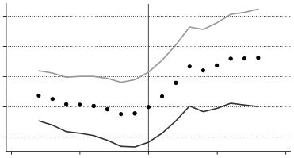

NOTE: figure/graphic rendered as an image from the PDF; its content is not machine-readable text. Caption (if any) follows as the next block.

To explore how social media can generate a network change, an event study is conducted that shows the relationship between the degree of having an information-rich network and the timing of the adoption. Each data point on the graph shows the coefficient estimates calculated from regressing brokerage on each month before and after the adoption event in the two-year observational period. After factoring out seasonality, individual fixed effects, and past performance, the coefficient estimate for months after the adoption event (*X >* 0) is increasing over time, indicating that Expertise-Find can induce a change in network position (Figure 4). Networks gradually become more information rich after the adoption, and the rate of the increase plateaus at around five months after the adoption. Collectively, these results show that, contrary to the notion that network positions are difficult to change due to individual traits and past actions, social media use has the potential to change individuals’ network positions over time. Having a search tool that allows employees to locate experts

**Figure 4 Event Study for When People Adopted Expertise-Find**

–0.2

–0.1

0

0.1

0.2

–10 –5 0 5 10

Coeffients_on_event_month Coeff_low Coeff_high

Event study: Structural diversity and technology adoption

Months since sign up

Notes. Each point on the graph is the coefficient estimate calculated from regressing brokerage or network diversity on each month before and after the adoption event after controlling for calendar month dummies, past billable revenue, and individual fixed effect. A value of 0 on the X-axis indicates that Expertise-Find was just adopted. Negative values on the X-axis indicate the number of months before the adoption has occurred and the positive values indicate the number of months that have passed since the adoption. From this graph, it shows that the effect on brokerage or having an informationrich network gradually goes up since the adoption event at X = 0.

in the firm empowers the employees to develop a more structurally autonomous and information-rich network.

Furthermore, because social media can induce a change in network positions, it can be used as an IV for network positions in establishing a causal relationship between network positions and performance. To estimate the validity of the instrument, I calculate the concentration parameter, which is 86.7, indicating that the adoption of Expertise-Find is not a weak instrument (Hansen et al. 2005).<sup>4</sup>

Next, I explore if the adoption is also correlated with work outcomes as shown in the reduced-form regressions. Table 3 shows that the adoption of Expertise-Find is positively associated with productivity, as measured by billable revenue and job security, as measured by the risk of layoff (or increasing job retention). After controlling for temporal shocks, individual fixed effects, and past work performance, Model 1 of Table 3 shows that the adoption of Expertise-Find is positively associated with generating an additional $584.15 in billable revenue (** = 584*0*15, *p <* 0*0*05). As with job security, the adoption is also positively correlated with job retention (** = 0*0*025, *p <* 0*0*05).<sup>5</sup> These results show that the use

4 The test for weak IV requires the concentration parameter to be greater than 10 (Hansen et al. 2005). Any value less than 10 indicates the presence of a weak instrument.

5 Because the layoff event has only one observation for each person, it is impossible to use the earlier IV approach that relies on the

**Table 3 Reduced-Form Regressions: Adoption on Billable Revenue, Retention, Information Diversity, and Social Communication**

[output not shown]

NOTE: table converted from PDF layout to HTML text; cell boundaries are reconstructed. See PDF if exact alignment matters.

Notes. Controls: Communication volume, past billable revenue, work divisions, geographical locations, and job ranks. Clustered standard error.

∗p < 001, ∗∗p < 0005, ∗∗∗p < 0001.

of social media, such as an expertise search tool, can have a significant impact on productivity and job security, with the mediating factor being the ability to improve the users’ network positions over time. Not only can social media induce a change in network structure, but this change is also associated with a significant improvement in various work outcomes. When used appropriately, social media can provide a potent means for individuals in the organization to manage their social networks and improve various work outcomes.

If social media enables superior work outcomes by helping individuals build a more information-rich network, it should also produce the same intermediate information benefits that an information-rich network is theorized to provide. Hence, I examine if the adoption of Expertise-Find can generate information diversity and social communication (Table 3, columns 3 and 4). For ease of comparison, each dependent variable is centered to have a mean of 0 and a standard deviation of 1. As shown in column 3, the adoption of Expertise-Find is positively correlated with information diversity (** = 0*0*626, *p <* 0*0*01). As users of Expertise-Find contact people residing in different pockets of the organizational network, they are also more likely to acquire information that they have not previously been exposed to. Hence, their information diversity may increase as well. Interestingly, social communication has also increased since the adoption (** = 0*0*153, *p <* 0*0*05), indicating referral

network change before and after the adoption. Instead, I use the number of months since a person has signed up for Expertise-Find to instrument for network diversity. As shown in Figure 4, network diversity gradually increases after a person has started to use the tool. Thus, other things being equal, early adopters should have more structurally diverse networks than late adopters. To test the validity of this instrument, I calculate the concentration parameter in the first-stage regression and the value is 11, slightly above the cutoff for the validity of the weak instrument test. The reducedform regression (Model 2) shows that the number of months passed after the adoption is positively correlated with job retention.

processes could also be at work, though the size of the estimate is much smaller. From field interviews, users of Expertise-Find were able to form some lasting relationships with individuals found using the tool. Some users have noted that the relationship has evolved beyond the purpose of one-time information acquisition; they have also interacted with the experts repeatedly and sometimes in social settings. Based on the empirical results, the adoption of Expertise- Find has a stronger effect on generating information diversity than social communication; the *t*-stat from the seemingly unrelated regressions shows the difference is statistically significant at *p* = 5% level. Thus, the primary benefit of Expertise-Find is information diversity, while social communication is secondary. Compared to gathering information, building a relationship takes time, and thus it is intuitive that the adoption social media has a bigger effect on information diversity. However, with a longer period of observation spanning many years, it would be possible to detect stronger effects of social communication from the adoption as people start to build relationships through using social media.

**The Effect of Network Positions on Billable Revenue and Layoffs** Next, I show whether a technology-induced change in network positions can improve productivity over time. Model 1 of Table 4 shows the OLS estimate on the correlation between having an informationrich network and billable revenue, after controlling for demographics and the work division as well as the managerial and technical rank of the person. This is what has been traditionally estimated in finding the relationship between having an informationrich network and performance in previous research. As shown in Model 1, the coefficient estimate for having a more information-rich network is positive and the effect is relatively large. A 1% increase in brokerage is correlated with billing $886 U.S. dollars in a month. However, when a fixed-effect specification is used (Model 2), the size of the coefficient is reduced by 17% (** = 733*0*0, *p <* 0*0*01). This shows that unobserved time-invariant individual characteristics could drive changes in both network positions and work performance. It is possible that the existing work load may drive the adoption of Expertise- Find as people seek to use this tool to help with their high work load. To address this potential bias, I controlled for the average monthly revenue in the past six months in Model 3. In addition, I also controlled for the propensity to use electronic communication by including the total number of electronic messages for each person. As shown in Model 3, having a more information-rich network continues to be positively correlated with billable revenue after controlling for

**Table 4 Information-Rich Networks and Worker Productivity**

[output not shown]

NOTE: table converted from PDF layout to HTML text; cell boundaries are reconstructed. See PDF if exact alignment matters.

Notes. Controls: Gender, managerial role, divisions, demographics, month dummies, and job ranks. Standard errors in parentheses.

∗p < 001, ∗∗p < 0005, ∗∗∗p < 0001.

past performance and the volume of communication. In Model 4, I estimated the effect of having a more information-rich network on billable revenue using the adoption of Expertise-Find as an IV. The coefficient estimate from this IV regression is reduced dramatically, by 73% (**information-rich network = 239*0*5, *p <* 0*0*05), demonstrating that time-varying individual heterogeneity can still bias the estimate upward. However, having a more information-rich network in the IV regression continues to be positive and statistically significant, indicating that it has an effect on improving work performance, though the effect is smaller than previously estimated.

I also examine if network positions can affect job security, specifically the likelihood to be laid off in January 2009 when the firm announced an unexpected and off-cycle cut in the work force amidst the recession. If network positions have an impact on work outcomes, they should have an even more pronounced impact on job security, because unlike promotions and performance evaluations, being laid off is a traumatic experience for most people, and network contacts can play an important role in preventing being laid off. Table 5 shows the crosssectional analysis for the effect of network positions on job security using the network constructed from six months of electronic communications prior to the layoff event.

The first model of Table 5 shows the effect of having a more information-rich network on job retention (1-layoffs). Gender and job roles do not show any statistically significant effect on job retention, but geographical locations appear to have an effect. Compared to the European Union, workers in the United States are more likely to be laid off. This difference is probably due to stronger labor laws in Europe, which make it harder for the firm to downsize. After

**Table 5 Information-Rich Networks and Layoff/Retention**

| Model | (1) | (2) | (3) | (4) |
| --- | --- | --- | --- | --- |
| Dependentvariable | Retention | Retention | Retention | Retention |
| Model | Probit | IVProbit | Probit | IVProbit |
| log(information-rich net): | 0128∗ 0 | 0107∗∗∗ 0 | 0155∗∗ 0 | 0107∗∗∗ 0 |
| log(1 -constraint) | 400755 0 | 400345 0 | 400775 0 | 400335 0 |
| Log(billablerevenue) |  |  | 0099∗∗ 0 | 0133∗∗∗ 0 |
|  |  |  | 400455 0 | 400495 0 |
| Gender (0 -male) | 0040 0 401365 0 | 0079 − 0 401235 0 | 0039 0 401375 0 | 0079 − 0 401235 0 |
| Europe | 0659∗∗∗ 0 401735 0 | 0393∗ 0 402225 0 | 0627∗∗∗ 0 401765 0 | 0393∗ 0 402225 0 |
| Asia | 0490∗∗ 0 402505 0 | 0411∗∗ 0 402055 0 | 0443∗ 0 402525 0 | 0411∗∗ 0 402055 0 |
| Australia | 0629∗ 0 | 0332 0 | 0608∗ 0 | 0332 0 |
|  | 403355 0 | 402305 0 | 403355 0 | 402305 0 |
| UnitedStates | 0387∗∗ − 0 | 0311∗∗ − 0 | 0449∗∗∗ − 0 | 0311∗∗ − 0 |
|  | 401545 0 | 401405 0 | 401595 0 | 401405 0 |
| Observations | 1927 , | 1927 , | 1927 , | 1927 , |

NOTE: table converted from PDF layout to HTML text; cell boundaries are reconstructed. See PDF if exact alignment matters.

Notes. Controls: Communication volume, job ranks, and divisions. Standard errors in parentheses.

∗p < 001, ∗∗p < 0005, ∗∗∗p < 0001.

controlling for the volume of electronic communication, I show that having a more information-rich network is positively correlated with job retention, but it is just short of being statistically significant at the 5% level (Model 1). In Model 2, I examine if there is a causal relationship between having an information-rich network and the likelihood of being laid off using the number of months a person has adopted Expertise-Find as an IV. Because the layoff data is cross-sectional, and thus fixed-effect models cannot be applied to eliminate heterogeneities at the individual level, I included several control variables such as demographics, gender, job role, and job rank. However, I am aware that there might still be unobserved variables that may drive both changes in network positions and the risk of being laid off. The IV estimation shows that the coefficient on having a more information-rich network is still positive, indicating that peripheral actors are more likely to be laid off than those who occupy more central positions in the network. However, it is possible that those with information-rich networks may just perform better and are for that reason less likely to be laid off. To address this issue, I control for the objective work performance using billable revenue. However, billable revenue is an endogenous variable because network positions can simultaneously affect billable revenue and the risk of being laid off. Hence, including billable revenue as an independent variable is problematic (Angrist and Pischke 2009). To address this problem, I use the lagged billable revenue six months before

measuring the network characteristics. The timing difference implies that the billable revenue is predetermined before network positions are calculated. Thus they are less likely to be the outcomes in the causal nexus (Angrist and Pischke 2009). Using billable revenue from an earlier period is also beneficial because it controls for possibilities that people who are finishing their current projects may also face increased risk of layoff when they do not have any future projects lined up. As expected, the objective performance, measured by billable revenue, is a strong predictor for job retention (or reduced risk of layoff). Similarly, having a more information-rich network continues to be positively correlated with job retention (Model 3, Table 5). If the main advantage to having this type of network is the access to relevant information and expertise that contribute to worker productivity, the billable revenue generated should capture the performance impact of having an information-rich network. But Model 3 shows that information-rich network positions provide additional shields against layoff, even after controlling for productivity and, interestingly, the effect of having an information-rich network is actually greater than that of billable revenue (**billable revenue = 0*0*099*1*information-rich network = 0*0*155). The *F* -test shows the difference is statistically significant at *p <* 0*0*001 level, demonstrating that an informationrich network can protect a worker from being laid off, beyond what it can provide in helping the person achieve superior work productivity.

Lastly, I examine if the relationship is causal using the number of months that have passed since a person has adopted Expertise-Find as an instrument for network position. Again, having an information-rich network is shown to have a significant impact on layoffs (** = 0*0*107, *p <* 0*0*01). To understand exactly how an information-rich network can improve job security as well as productivity, I examine the information benefits derived from an information-rich network. In particular, I focus on information diversity and social communications and their impacts on various work outcomes.

**Information Diversity, Social Communication, and Information-Rich Networks** While an information-rich network has been theorized to provide information benefits, whether these benefits actually exist and how they differ in affecting work outcomes is rarely examined. Thus, it is important to quantify these benefits and examine how they affect work outcomes differently. I focus on two particular types of information benefits that characterize an information-rich network: information diversity and social communication. Information diversity is calculated as the topic dissimilarity score in a person’s electronic communications.

Social communication is calculated using a friendship index that measures the frequency of words in the messages that are related to socializing and informal activities. While information diversity measures the heterogeneity of the communication content, social communication can be interpreted as the intensity of a specific type of information. Information heterogeneity is helpful for work performance because it enables individuals to access information they need. Social communication is important because it contributes to the referral process. People with whom one socializes are more likely to be one’s friends and advocates, trumpeting one’s accomplishments at key junctures such as during layoffs.

Table 6 shows the relationship between information diversity and having an information-rich network, and between social communication and having an information-rich network. I find strong evidence supporting that an information-rich network can be characterized by both information diversity and social communication. Using a fixed-effect model, having a more information-rich network is positively correlated with an increase in information diversity (**information-rich network = 2*0*198, *p <* 0*0*01). The effect continues to be positive (** = 7*0*807, *p <* 0*0*05) when the IV approach is used. Similarly, the fixed-effect model shows that a one standard deviation increase in having a more information-rich network is correlated with gaining 0.01 points in the friendship index, which is about a 1% increase (Model 3). The relationship continues to hold (**information-rich network = 0*0*216, *p <* 0*0*05) when the IV approach is used. Considering information diversity as instrumental and social communication as expressive, these results show that an information-rich network can have both

**Table 6 Relationships among Information-Rich Networks, Information Diversity, and Social Communication**

| Model | (1) | (2) | (3) | (4) |
| --- | --- | --- | --- | --- |
| Dependent | Information | Information | Friendship | Friendship |
| variable | diversity | diversity | index | index |
| Model | FE | IV | FE | IV |
| Information-rich | 21980∗∗∗ 0 | 78070∗∗ 0 | 0010∗∗∗ 0 | 0216∗∗ 0 |
| net(standardize) | 4032705 0 | 4398005 0 | 400035 0 | 401055 0 |
| Volumeofemail/ | 00170∗∗∗ 0 | 00090 0 | 7 .39e−05∗∗∗ 4 .79e−05∗∗∗ |  |
| IM/calendarevents | 4000045 0 | 4000025 0 | (2 .92e−06) | (1 .37e−05) |
| Billablerevenue | 00002∗∗∗ − 0 | 00005 0 | 4 .03e−08 | 9 .90e−07 |
|  | (5118 04) . − | 4000095 0 | (4 .29e−07) | (6 .89e−07) |
| Observations | 9666 , | 9666 , | 15634 , | 15634 , |
| R -squared | 00270 0 | — | 0064 0 | — |
| Numberofpeople | 1912 , | 1912 , | 1912 , | 1912 , |

NOTE: table converted from PDF layout to HTML text; cell boundaries are reconstructed. See PDF if exact alignment matters.

Notes. Controls: Month dummies and individual fixed effect. Standard errors in parentheses.

∗p < 001, ∗∗p < 0005, ∗∗∗p < 0001.

types of information benefits, supporting Hypotheses 2A and 2B. This contrasts with prior views that it is difficult to have both instrumental and expressive relationships in a network. However, there are still trade-offs.

**Information Diversity, Social Communication, and Their Relations to Billable Revenue and Layoffs** While it is possible to have both information diversity and social communication in an information-rich network, they differ in affecting worker productivity and job security. Table 7 shows the effect of information diversity and social communication on productivity as measured by monthly billable revenue. To make a comparable comparison between the two information benefits, both variables are centered to have a mean of 0 and a standard deviation of 1. Model 1 shows that a one standard deviation increase in information diversity is correlated with generating an additional $427.80 of billable revenue. However, the friendship index that captures social communication is not statistically significantly correlated with billable revenue (Model 2). Treating both information diversity and the friendship index as independent variables in the same model (Model 3), I find that information diversity, but not the friendship index, is positively correlated with generating billable revenue. The *F* -tests using the estimates in Models 3 and 4 show that the effect of information diversity is greater than the effect of social communication at the *p <* 0*0*05 level. Overall, these results support Hypothesis 3A.

Next, I explore whether information diversity and the friendship index are complements or substitutes. By adding the interaction between information diversity and the friendship index in the model, Model 4 shows a negative interaction effect, though only statistically significant at the *p <* 0*0*1 level. I also examined

**Table 7 Network Positions and Performance: Information Diversity and Social Communication**

| Model | (1) | (2) | (3) | (4) |
| --- | --- | --- | --- | --- |
| Dependent | Monthly | Monthly | Monthly | Monthly |
| variable | revenue | revenue | revenue | revenue |
| Model | FE | FE | FE | FE |
| Informationdiversity | 4278∗∗∗ 0 |  | 4421∗∗∗ 0 | 2284∗∗ , |
| (standardized) | 416355 0 |  | 416375 0 | 498775 0 |
| Friendshipindex |  | 4276 0 | 1878 0 | 1168 − 0 |
| (standardized) |  | 466865 0 | 411945 0 | 420055 0 |
| Informationdiversity ×Friendshipindex |  |  |  | 1909∗ − 1 (1009) , |
| Observations Numberofpeople | 20373 , 2038 , | 20373 , 2038 , | 20373 , 2038 , | 20373 , 2038 , |

NOTE: table converted from PDF layout to HTML text; cell boundaries are reconstructed. See PDF if exact alignment matters.

Notes. Controls: Communication volume, past billable revenue, month dummies, and individual fixed effect. Standard errors in parentheses.

∗p < 001, ∗∗p < 0005, ∗∗∗p < 0001.

**Table 8 Correlations between Information Diversity and Social Communication**

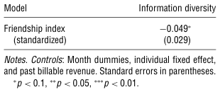

NOTE: complex table shown as an image of the PDF; the text below is a rough machine extraction and may be mis-aligned.

**extracted text (unreliable layout)**

the correlation between the two in Table 8. After controlling for temporal shocks, individual fixed effects, and past performance, the correlation between information diversity and the friendship index is negative (** = −0*0*049, *p <* 0*0*1). The negative correlation and the negative interaction effect together indicate that information diversity and the friendship index are substitutes for generating billable revenue. Having a high friendship index reduces the effect of information diversity on generating billable revenue. One might argue that people may learn from each other through social communication, and that increased social communication could increase the diversity of information as well. In this case, the information acquired through social communication would still be captured by the information diversity measure that calculates the diversity of topics in one’s electronic messages, regardless of how the information is acquired. It could come from social communication or it could come from more formal channels. Thus the effect of social communication in Models 3 and 4 has already taken information diversity into account. For the same level of information diversity, an increase in social communication has a negligible effect on productivity. While these results show that an information-rich network enabled by social media can generate both expressive and instrumental elements, as shown by information diversity and social communication, respectively, there is a trade-off between the two in generating billable revenue. Information diversity seems to be the main mechanism driving productivity improvements.

Next, in Table 9, I explore the effect of information diversity and the friendship index on job security (reducing risk of layoff). The first model shows the correlation between information diversity and job retention after controlling for demographics, gender, job ranks, regions, and business divisions. Contrary to the result in the productivity analysis, information diversity is no longer correlated with job retention (Model 1). However, Model 2 shows that the friendship index is positively associated with job retention (** = 0*0*191*1p <* 0*0*05). When both information diversity and the friendship index are jointly used in the model, the friendship index is still positively associated with job retention but the coefficient on information diversity is not. The *F* -test shows that the effect

**Table 9 Networks and Layoff Risks: Information Diversity vs. Social Communication**

| Model | (1) | (2) | (3) | (4) | (5) | (6) | (7) |
| --- | --- | --- | --- | --- | --- | --- | --- |
| Dependent |  |  |  |  |  |  |  |
| variable | Retention | Retention | Retention | Retention | Retention | Retention | Retention |
| Model | Probit | Probit | Probit | Probit | Probit | Probit | Probit |
| Informationdiversity | 0088 0 |  | 0102 0 | 0108 0 |  | 0122 0 | 0115 0 |
| (standardized) | 400755 0 |  | 400765 0 | 400785 0 |  | 400795 0 | 400805 0 |
| Friendshipindex (standardized) |  | 0191∗∗ 0 400965 0 | 0199∗∗ 0 400955 0 |  | 0169∗ 0 400955 0 | 0180∗ 0 400955 0 | 0157∗ 0 400925 0 |
| Informationdiversity ×Friendshipindex |  |  |  |  |  |  | 0168∗ − 0 400995 0 |
| Log(billablerevenue) |  |  |  | 0133∗∗∗ 0 | 0118∗∗ 0 | 0125∗∗ 0 | 0130∗∗∗ 0 |
|  |  |  |  | 400495 0 | 400505 0 | 400505 0 | 400505 0 |
| Log(friends’ |  |  |  | 0024 − 0 | 0005 − 0 | 0033 − 0 | 0036 − 0 |
| billablerevenue) |  |  |  | 400695 0 | 400675 0 | 400705 0 | 400715 0 |
| Observations | 1927 , | 1927 , | 1927 , | 1927 , | 1927 , | 1927 , | 1927 , |

NOTE: table converted from PDF layout to HTML text; cell boundaries are reconstructed. See PDF if exact alignment matters.

Notes. Controls: Communication volume, gender, job rank dummies, regional dummies, and business division dummies. Standard errors in parentheses.

∗p < 001, ∗∗p < 0005, ∗∗∗p < 0001.

of the friendship index is greater than that of information diversity at the *p <* 0*0*01 level. This set of results suggests that social communication is more important for avoiding layoffs than is information diversity. This is the exact opposite from the productivity analysis, where information diversity is more correlated with generating billable revenue than is social communication.

Because work performance could also have a significant impact on layoffs, I control for the average billable revenue for the six months prior to the layoff event (Models 4–7, Table 9). All else being equal, results indicate that high performers are more likely to be retained than low performers. It is also possible that people contribute indirectly to firm profits by helping their colleagues. Thus, I control for the billable revenue of the network contacts in Models 4–7. On average, friends’ billable revenue is not correlated with job retention. As with the results in Models 1–3, I find that compared to information diversity, social communication as measured by the friendship index is more correlated with job retention (Model 6). The *F* -test shows that the coefficient of the friendship index is greater than that of information diversity in increasing job retention (*p <* 0*0*01). Together these results demonstrate that social communication is the primary channel through which an informationrich network drives job retention, lending support to Hypothesis 3B.

Next, I explore whether information diversity and social communication are substitutes in preventing layoffs. Model 7 shows that the interaction effect of information diversity and the friendship index is negative and statistically significant *p <* 0*0*1, indicating a plausible substitutive relationship. I hypothesize that

the negative interaction occurs because one has only limited time and energy for either gathering diverse information or socializing. Spending more time on one may result in less time to spend on the other. Thus, I show that an information-rich network can have both instrumental and expressive elements, contrary to the notion that it is rare to have both. However, the tradeoff re-emerges in the ability of a person to mobilize *either* information diversity *or* social communication to achieve a desired work outcome. The substitutive relationship between the two shows the limitation in mobilizing them together. The return from investing in social communication will dampen the return to investment in information diversity. While access to diverse information is helpful for productivity, it takes away time from forming friendships or alliances that are helpful for job security.

**Discussion and Conclusion** In this study, I examine if social media can induce a change in network positions and whether this change has an impact on work outcomes. By observing the adoption of a social networking tool inside a large information technology firm, I show that social media can transform individuals’ network positions over time. Contrary to the notion that network positions are extremely difficult to change because of past actions, history, and personality traits (Powell et al. 2005), I find that social media can potentially disrupt the existing inertia inside an organizational network. Observing a network change generated by social media, I show evidence of a causal relationship between having an information-rich network and worker productivity and between having an information-rich network and job security.

Because Expertise-Find can change a person’s network position primarily through information-seeking activities, the improvement in work outcomes is likely to come from the information benefits derived from having a more information-rich network (Burt 1992). However, these benefits have rarely been observed and quantified. Furthermore, different types of information benefits may have divergent and at times conflicting implications for various performance measures. Thus, to understand precisely how network positions impact work outcomes, I examine two different types of information benefits—information diversity and social communication—using the digital trace from people’s daily communications. Applying advanced machine learning techniques to assess the content of people’s electronic communications, I measure the diversity of information by finding distinct topics in a person’s communications. To measure social communication, I calculate a friendship index that captures the frequency of words in the electronic communications that are related to informal and social activities. Observing a network and information change before and after the adoption, I show that an information-rich network enabled through social media can generate both social communication and information diversity.

While having access to a heterogeneous body of information can be helpful for productivity, having a high intensity of a certain type of information, such as social communication, may also be helpful. To understand their impacts on various work outcomes, I examine how information diversity differs from social communication in improving work productivity and job security. Comparing information diversity with social communication, I show that the former is positively correlated with generating billable revenue, whereas the latter is not. However, I find that in the case of job security, social communication is positively associated with retention, while information diversity is not. Viewing information benefits as instrumental and social communication as expressive, I show that it is possible to have both in an information-rich network. However, there are also trade offs. Not only do they have different effects on various work outcomes, I show that information diversity and social communication are substitutes for improving productivity and job security. This result suggests a trade off in the returns from investing in instrumental (information diversity) or expressive elements (social communication) in an information-rich network.

Overall, these results demonstrate the transformative value of social media in changing individuals’ network positions within an organization. Future work should explore whether such change is long lasting when more people adopt social media. In this

setting, about a quarter of the consultants adopted the tool and reaped benefits from the adoption. Thus, there remains the question of whether the value of this social networking tool will continue to be positive when the majority of the organization has adopted it. It is possible that its use is a zero-sum game, such that individuals using the tool only take existing work from other consultants; or it could be that the overall performance of the firm improves as a result. Thus, understanding the long-term implications of social media for performance has tremendous value to organizations. Depending on the nature of these implications, firms may need dramatically different strategies for managing social media.

**Acknowledgments** The author is grateful to Ching-yung Lin, Erik Brynjolfsson, Roberto Fernandez, Ray Reagans, Sinan Aral, and three anonymous reviewers for valuable comments. The author also thanks the United States Army Research and the MIT Center for Digital Business for generous funding.

#### **References**

Ancona DG, Caldwell DF (1992) Demography and design: Pre-

dictors of new product team performance. *Organ. Sci.* 3(3): 321–341. Angrist J, Pischke J (2009) *Mostly Harmless Econometrics* (Princeton

University Press, Princeton, NJ). Aral S, Van Alstyne M (2011) The diversity-bandwidth tradeoff.

*Amer. J. Sociol.* 117(1, July):90–171. Aral S, Brynjolfsson E, Van Alstyne M (2012) Information, technol-

ogy, and information worker productivity. *Inform. Systems Res.* 23(3, Part-2):849–867. Bales RF, Slater P (1955) Role differentiation in small decision-

making groups. Parsons T, Bales RF, eds. *Family, Socialization and Interaction Process*, Chapter V (Free Press, Glencoe, IL). Blei D, Ng A, Jordan M (2003) Latent Dirichlet allocation. *J. Machine*

*Learn. Res.* 3(January):993–1022. Borgatti S, Cross R (2003) A relational view of information seeking

and learning in social networks. *Management Sci.* 49(4):432–445. Borgatti S, Foster P (2003) The network paradigm in organizational

research: A review and typology. *J. Management* 29(6):991–1013. Burt R (1992) *Structural Holes: The Social Structure of Competition*

(Harvard University Press, Cambridge, MA). Burt R (2000) The network structure of social capital. Staw B,

Sutton R, eds. *Research in Organizational Behavior*, Vol. 22 (JAI Press, New York). Burt R (2004) Structural holes and good ideas. *Amer. J. Sociol.*

110(2):349–399. Burt R (2007) Secondhand brokerage: Evidence on the importance

of local structure for managers, bankers, and analysts. *Acad. Management J.* 50(1):110–148. Burt R (2008) Information and structural holes: Comment on

Reagans and Zuckerman. *Indust. Corporate Change* 17(5): 953–969. Burt R, Ronchi D (2007) Teaching executives to see social capital:

Results from a field experiment. *Soc. Sci. Res.* 36(3):1156–1183. Cross R, Cummings J (2004) Tie and network correlates of per-

formance in knowledge intensive work. *Acad. Management J.* 47(6):928–937. Etzioni A (1965) Dual leadership in complex organizations. *Amer.*

*Sociol. Rev.* 30(5):688–698. Fernandez RB (1991) Structural bases of leadership in intraorgani-

zational networks. *Soc. Psych. Quart.* 54(1):36–53.

Fombrun CJ (1982) Strategies for network research in organizations.

*Acad. Management Rev.* 7(2):280–291. Friedkin N (1982) Information flow through strong and weak

ties in intraorganizational social networks. *Soc. Networks* 3(1982):273–285. Goldstein DG, Gigerenzer G (1999) The recognition heuristic: How

ignorance makes us smart. Gigerenzer G, Todd PM, eds. *Simple Heuristics That Make Us Smart* (Oxford University Press, Oxford, UK). Goldstein DG, Gigerenzer G (2002) Models of ecological rationality:

The recognition heuristic. *Psych. Rev.* 109:75–90. Granovetter M (1973) The strength of weak ties. *Amer. J. Sociol.*

78(6):1360–1380. Granovetter M (1982) The strength of weak ties: A network theory

revisited. Marsden PV, Lin N, eds. *Social Structure and Network Analysis* 1:201–233. Hansen C, Hausman J, Newey W (2005) Many Weak Instruments

and Microeconometric Practice. (July) Mimeo. Hansen M (1999) The search-transfer problem: The role of weak ties

in sharing knowledge across organization subunits. *Admin. Sci. Quart.* 44(1):82–111. Hargadon A, Sutton R (1997) Technology brokering and innova-

tion in a product development firm. *Admin. Sci. Quart.* 42(4): 716–749. Homans GC (1974) *The Human Group, Social Behavior: Its Elementary*

*Forms* (Harcourt, Brace and World, New York). Ibarra H (1995) Race, opportunity, and diversity of social circles in

managerial networks. *Acad. Management J.* 38(3):673–703. Kossinets G, Watts D (2006) Empirical analysis of an evolving social

network. *Science* 311(5757):88–90. Krackhardt D (1995) Entrepreneurial opportunities in an entrepreneurial firm: A structural approach. *Entrepreneurship Theory and Practice* 19(3):53–69. Krackhardt D, Kilduff M (1999) Whether close or far: Social distance

effects on perceived balance in friendship networks. *J. Personality Soc. Psych.* 76(5):770–782. Krackhardt D, Porter L (1985) When friends leave: A structural

analysis of the relationship between turnover and stayer’s attitudes. *Admin. Sci. Quart.* 30(2):242–261. Kumbasar E, Romney AK, Batchelder WH (1994) Systematic biases

in social perception. *Am. J. Sociology* 100(2):477–505. Lin CY, Ehrlich K, Griffiths-Fisher V, Desforges C (2008) SmallBlue:

People mining for expertise search. *IEEE MultiMedia at Work* 15(1):78–84. Lin N (2001) *Social Capital: A Theory of Social Structure and Action*

(Cambridge University Press, Cambridge, UK). Lincoln JR, Miller J (1979) Work and friendship ties in organiza-

tions: A comparative analysis of relational networks. *Admin. Sci. Quart.* 24(2):181–199.

Marsden P (1990) Network data and measurement. *Annual Rev.*

*Sociol.* (16):435–463. Marsden P (2005) Recent developments in network measurement.

Carrington PJ, Scott J, Wasserman S, eds. *Models and Methods in Social Network Analysis* (Cambridge University Press, New York), 8–30. Munshi K (2003) Networks in the modern economy: Mexican

migrants in the U.S. labor market. *Quart. J. Econom.* 118(2): 549–599. Piskorski M, Eisenmann T, Chen D, Feinstein D (2011) Face-

book. Harvard Business School Case 808128, Harvard Business School Press, Boston. Podolny J (2001) Networks as the pipes and prisms of the market.

*Amer. J. Sociol.* 107(1):33–60. Podolny J, Baron J (1997) Resources and relationships: Social net-

works and mobility in the workplace. *Amer. Sociol. Rev.* 62(5): 673–693. Powell W, Koput K, White D, Smith O (2005) Network dynamics

and field evolution: The growth of interorganizational collaboration in the life sciences. *Amer. J. Sociol.* 110(4):1132–1205. Reagans R, McEvily B (2003) Network structure and knowledge

transfer: The effects of cohesion and range. *Admin. Sci. Quart.* 48(2):240–267. Reagans R, Zuckerman E (2001) Networks, diversity, and produc-

tivity: The social capital of corporate R&D teams. *Organ. Sci.* 12(4):502–517. Rodan S, Galunic D (2004) More than network structure: How

knowledge heterogeneity influences managerial performance and innovativeness. *Strategic Management J.* (25):541–562. Shah PP (2000) Network destruction: The structural implications of

downsizing. *Acad. Management J.* 43(1):101–112. Slater PE (1965) Role differentiation in small groups. *Amer. Sociol.*

*Rev.* 20(3):300–301. Snijders T (1999) Prologue to the measurement of social capital. *The*

*Tocqueville Rev.* 10(1):27–44. Wen Z, Lin CY (2010) Towards finding valuable topics. *SIAM Inter-*

*nat. Conf. Data Mining* (SIAM, Philadelphia), 720–731. Wu F, Huberman B, Adamic L, Tyler J (2004) Information flow in

social groups. *Physica A* 337(1):327–335. Wu L, Lin C, Aral S, Brynjolfsson E (2009) Network structure

and information worker productivity: New evidence from the global consulting services industry. *Winter Conf. Bus. Intelligence* (University of Utah, Salt Lake City). Zaheer A, Bell G (2005) Benefiting from network position: Firm

capabilities, structural holes, and performance. *Strategic Management J.* 26(9):809–825.